# Survey Modes and the Total Survey Error Framework

PUBHBIO 7225 Lecture 2

Generative AI acknowledgment: MS Copilot was used to generate alt text for images and to create icons for survey modes

## Outline

**Topics**

- Designing Survey Questions
- Survey Modes
- Total Survey Error (TSE) framework

**Activities**

- 2.1 Survey Questions
- 2.2 OPAS Sources of Error

**Readings**

- Dillman DA and Christian LM (2005). Survey Mode as a Source of Instability in Responses across Surveys. *Field Methods*, 17(1), 30-52. (PDF on Carmen)

**Assignments**

- Problem Set 1 due Thursday 9/4/25 11:59pm via Carmen
- Peer Evaluation of Problem Set 1 due Tuesday 9/9/25 11:59pm via Carmen

## Designing Survey Questions

Assuming the observation unit is a **person**, questions should be …

- Simple and clear
  - Beware words that might be interpreted differently by different people, or might not be understood by some people
- Specific, not general
  - (not good) “Have you ever been attacked?”
  - (better) “Has anyone ever attacked you in any of these ways: (a) With any weapon, for example, a gun or knife, (b) With anything like a baseball bat, frying pan, scissors…”
- Related to the concept of interest
  - Reusing questions from previous surveys allows for historical comparison – if appropriate for the audience/topic
- Carefully ordered
  - Responses to a question may be unduly influenced by question(s) that preceded it
  - Usually best to ask more general question first, followed by specific question(s)

## Designing Survey Questions

Questions should be (cont.)…

- Not leading or “loaded” questions
  - Questions can be written to lead the respondent to the answer you want to hear — don’t do this!
- Not written as double-negatives
  - (not good) “Do you favor or oppose not allowing drivers to use cell phones while driving?”
  - (better) “Do you agree with laws banning cell phone use while driving?”
- Not double-barreled
  - Be sure to ask only one concept per question
- If closed-ended, all response options are available
  - Make sure all respondents would be able to endorse *at least one* answer
- If multiple-choice/forced-choice, response options are mutually exclusive and exhaustive
  - Make sure all respondents would be able to select *just one* answer

## Activity 2.1 (Part 1)

Survey Questions (Part 1)

## Survey Modes

Four ways we could get information from a sampled person, called the **survey mode**:

[figure not shown]

**Face-to-Face**

[figure not shown]

**Mail**

[figure not shown]

**Phone**

[figure not shown]

**Internet**

High-level differences include:

- Cost
- Use or non-use of an interviewer
- Availability of visual aids
- Enforcement of “skip patterns”
- Issues with the frame
- Types of biases likely to be present
- Availability of (and types of) paradata
  - Paradata = data collected about the survey process (e.g., how long the interview took)

## Mode: Face-to-Face

Survey completed in-person via an interviewer, traditionally via door-to-door canvassing (considered “gold standard”)

**Pros:**

**Cons:**

**Frame Considerations:**

## Mode: Mail/Written

Survey completed by respondent with paper and pencil (“PAPI”), usually sent via mail

**Pros:**

**Cons:**

**Frame Considerations:**

## Mode: Phone

Survey completed over the phone – in practice, usually “CATI” (Computer Aided Telephone Interview) where computer is used by interviewer (not by respondent)

**Pros:**

**Cons:**

**Frame Considerations:**

## Mode: Internet

Survey completed online, often called “CAWI” (Computer Aided Web Interview)

**Pros:**

**Cons:**

**Frame Considerations:**

## Activity 2.1 (Part 2)

Survey Questions (Part 2)

## Survey Errors

Historically, survey methodologists described errors as “Sampling Errors” and “Non-Sampling Errors”

More modern approach is the **Total Survey Error approach**

**Total Survey Error** = difference between population parameter (the truth) and the estimate of that parameter based on a sample survey

**Two types of survey error:**

1. **Random error** – random fluctuation from sample to sample
   - Should “cancel out” in terms of bias of the sample estimate but will increase variance (reduce precision)
2. **Systematic error** – e.g., underreporting of sensitive behaviors
   - Biases the sample estimate systematically away from the true value

## Sources of Errors: Two Categories

- **Measurement Errors** – how well the (edited) survey responses obtained from a respondent reflect the underlying construct being measured
  - Errors that *could occur* even with a census
- **Representation Errors** – how well the (weighted) sample represents the target population
  - Errors that *would not occur* if we had a census (measured entire population)

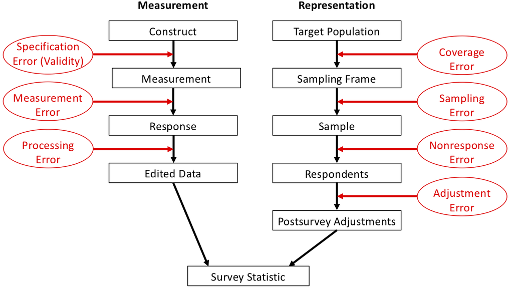

Adapted from Groves et al. (2009), Survey Methodology, 2nd Edition

## TSE Components Aﬀecting Measurement

1. **Specification Error (Validity)** – error arising when the construct being measured is operationalized (turned into survey questions) in an invalid way; questions do not properly measure the underlying construct
2. **Measurement Error** – the measured response diﬀers from the true value (many possible reasons), which is especially problematic when asking people questions
   - Some sources of measurement error:
     - lying
     - not understanding or misinterpreting the question
     - forgetting/recall bias
     - diﬀerent responses in diﬀerent survey modes
     - interviewer eﬀects
     - diﬀerent responses to diﬀerent interviewers
     - social desirability
     - satisficing (choosing “easy” answers to reduce response burden)
     - question order
     - question wording
3. **Processing Error** – data entry errors and coding errors, for example, from coding open-ended responses or classifying occupations

## TSE Components Aﬀecting Representation

1. **Coverage Error** – mismatch between target population and sampling frame
   - **Undercoverage** – some members of the target population are not in sampled population
   - **Overcoverage** – sampling frame contains units that are not in the target population
2. **Sampling Error** – error that results from taking a sample rather than evaluating the whole population (variability inherent in using a random subset of the population for estimation)
3. **Nonresponse Error** – not all sampled units respond/provide complete data, and responses from the units who do participate may be diﬀerent from the responses from units who do not participate (if they had been observed)
   - **Unit nonresponse** – a sampled unit provides no data at all
   - **Item nonresponse** – a sampled unit provides some data, but some items have missing values
4. **Adjustment Error** – error arising when the sample is adjusted for design eﬀects (i.e., the “complex design”) via weighting or other techniques (poststratification, calibration), possibly including adjustments for nonresponse

## Selection Bias

All these representation-related errors can lead to **Selection Bias**

- Arises when some part of the target population is not in the sampled population
- Occurs when the actual probabilities with which units are sampled diﬀer from the specified selection probabilities
- Is most obviously a problem for non-probability samples, but can also arise with probability samples

[figure not shown]

[Figure source](https://xkcd.com/2618/)

## Activity 2.2

OPAS Sources of Error